# Measurement Strategy, ESM 228

Gavriella Keyles, Kyle Monper, Jeremy Knox

5/4/2020

This measurement strategy concerns the Water Wise Landscaping program in the City of Santa Barbara. The following questions were developed to measure the impacts of the program. The program’s theory of change encompasses the following activities, outputs, outcomes and goals:

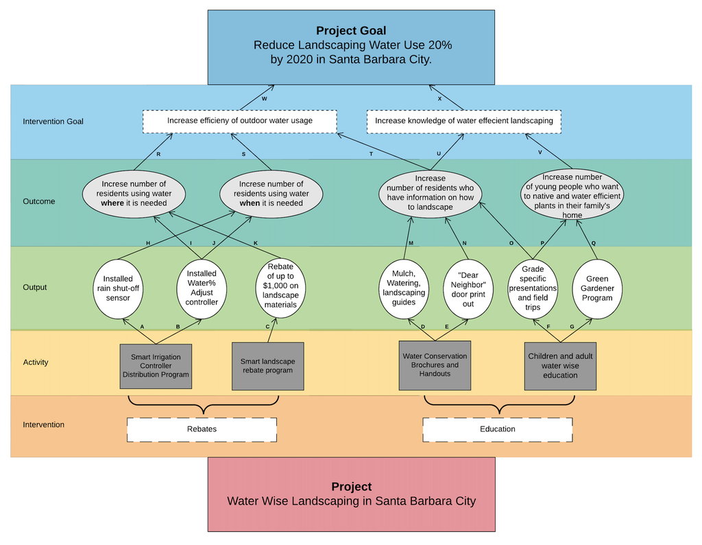

## Question 1

**Measurement goal** Assess effectiveness of classroom presentation for getting students excited to plant native plants at home

**Unit of measure** Survey responses from individual students who have received programming

**Source of data** Survey handout

**Rationale for choice of measure** This question will measure the impact of the presentation on getting students excited to get their family to plant native plants at home.

**Responsibility for data collection** Survey will be left with teachers by presenters, with a stamp and envelope to return the results.

**Frequency of data collection** This will be asked twice, once one day after the presentation, and again one month later, which is when the next question (question 2) will also be asked.

## Question 2

**Measurement goal** Assess effectiveness of classroom presentation for *actually* getting students to plant native plants at home

**Exact Measure to be taken**: Since receiving the classroom presentation have you or your family planted native plants in your yard at home? a) Yes  
b) No  
c) I did not receive the presentation  
d) I do not have a yard at home

**Unit of measure** Survey responses from individual students who have received programming

**Source of data** Survey handout

**Rationale for choice of measure** This question combined with question 1 (with paired anonymous survey IDs) will test whether/to what degree students can influence their family to plant native plants at home. The paired structure will allow for matched data to see whether students who were excited one month ago have acted on that excitement and were able to get their family to plant natives.

**Responsibility for data collection** Survey will be mailed or dropped off to teachers by presenters at randomly selected classroom after presenting. Inlcuded will be a stamp and envelope to return the results.

**Frequency of data collection** Once, one month after classroom presentation

## Question 3

**Measurement goal** Residential water usage

**Exact Measure to be taken**: In the last year, has your water utility bill a) Increased b) Decreased c) Remained the same d) Don’t know

**Unit of measure** Actual residential water usage (cubic feet)

**source of data** Survey handout, could be supplemented by residential water bills, City of Santa Barbara Water Utility data

**Rationale for choice of measure** While it is not possible to determine causality from water usage data, it is important to observe whether water usage did decline in any measurable way, especially when combined with other survey questions related to awareness of water-smart landscaping or use of the rebate program

**Responsibility for data collection** Survey will be mailed or hung on doorknobs to a random sample of 500 Santa Barbara households (350 owned homes, 150 rented homes).

**Frequency of data collection** Once, one year after program implementation